# 1b VLAIO-effect Analysis — Does Public Funding Strengthen the Private Network?

### Interpretatie Q5 — Komt VLAIO vóór of na privaat kapitaal?

1. **75% van de startups ontvangt private investering EERST** — VLAIO-subsidie volgt typisch ~14 maanden later (mediaan -14.5 maanden). Dit is statistisch zeer significant (t=-12.74, p<0.001).
2. **Slechts 25% krijgt VLAIO eerst**: Bij een kwart van de bedrijven gaat de publieke subsidie vooraf aan private investering. Dit zijn mogelijk de cases waar VLAIO wél katalytisch werkt.
3. **De verdeling is links-scheef**: De bulk van de gap zit tussen -60 en 0 maanden — private investering komt typisch 1-5 jaar vóór VLAIO.

> **Beleidsammo**: VLAIO is overwegend een **verdiepings- en opschalingsinstrument**, geen katalysator voor eerste private financiering. Het versterkt bedrijven die al private validatie hebben. De 25% waar VLAIO wél eerst komt verdient nader onderzoek — zijn dat de deep-tech bedrijven (OND/Baekeland) waar private investeerders langer aarzelen? (Zie Q5b voor verdieping.)

### Interpretatie Q5b — Welk type privaat kapitaal komt eerst?

```
================================================================================
Q6: FUNDING MULTIPLIER
================================================================================

Private funding comparison (startups with known amounts):
Metric                                VLAIO    Non-VLAIO      Ratio
------------------------------------------------------------------
  Total private ($M)                   2.20         1.10       2.0x
  Number of rounds                     1.00         1.00       1.0x
  Avg round ($M)                       1.64         0.77       2.1x

Mann-Whitney U (VLAIO > non-VLAIO total): p=0.000034 ✅

Funding multiplier ($USD private / €EUR VLAIO, not FX-adjusted):
  Median: 4.5x
  Mean:   14.8x
  25th:   1.8x
  75th:   12.8x
  (n=260 companies with both amounts, excl. outliers >1000×)
```

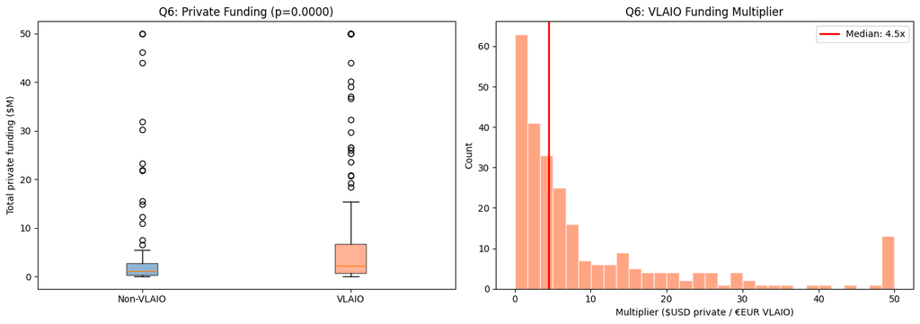

### Interpretatie Q6 — Funding Multiplier

> **Beleidsammo**: De 4.5× multiplier is een sterk argument voor VLAIO-financiering als hefboom. Ter vergelijking: Europese benchmarks voor publieke R&D-subsidies liggen rond 2-3×. Vlaanderen scoort bovengemiddeld, zelfs rekening houdend met de USD/EUR-marge.

# B. Meso Level — Sub-network Comparison

Run full Noak resilience metrics on sub-networks defined by VLAIO funding status.

```
================================================================================
Q7: SUB-NETWORK NOAK COMPARISON
================================================================================

Sub-network sizes:
  VLAIO investors:     275 nodes, 663 edges
  Non-VLAIO investors: 59 nodes, 37 edges
  Full network:        334 nodes, 786 edges

Calculating Noak metrics (this may take a minute)...

Metric                         VLAIO investors  Non-VLAIO investors         Full network
----------------------------------------------------------------------------------------
  nodes                                    275                    5                  334
  edges                                    663                   10                  786
  density                               0.0176               1.0000               0.0141
  avg_closeness                         0.3545               1.0000               0.3559
  transitivity                          0.1569               1.0000               0.1244
  n_communities                             11                    1                   18
  avg_comm_size                        25.0000               5.0000              18.5556
  avg_path_length                       2.8747               1.0000               2.8634
  diameter                                   6                    1                    6
  avg_degree                            4.8218               4.0000               4.7066
```

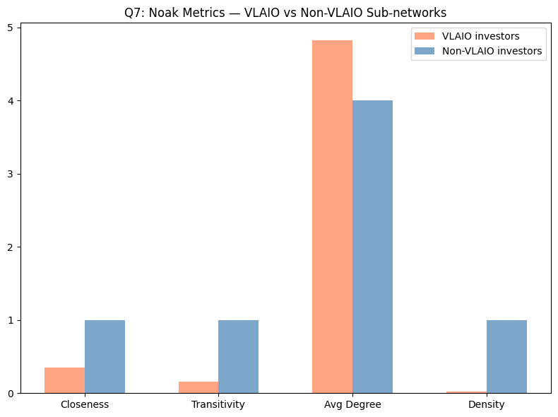

### Interpretatie Q7 — Is het VLAIO sub-netwerk veerkrachtiger?

1. **VLAIO-investeerders vormen één groot verbonden netwerk** (275 nodes, 663 edges, density 0.018). Het non-VLAIO sub-netwerk is volledig gefragmenteerd: 59 nodes verdeeld over tientallen mini-componenten, waarvan de grootste slechts 5 nodes bevat.
2. **Clustering zit volledig bij VLAIO** (transitivity 0.16 in LCC): De co-investerings-"driehoeken" — A investeert met B, B met C, én A met C — bestaan in het VLAIO-deel van het netwerk. Het non-VLAIO deel is te gefragmenteerd voor betekenisvolle clustering.
3. **4.8 gemiddelde degree** in het VLAIO LCC: VLAIO-investeerders zijn met gemiddeld bijna 5 peers verbonden. Dit wijst op een rijk, verweven investeerdersecosysteem met 11 communities.
4. **Non-VLAIO investeerders opereren geïsoleerd**: De 59 investeerders die alleen in non-VLAIO bedrijven investeerden zijn nauwelijks met elkaar verbonden. Ze vormen geen coherent sub-netwerk.

> **Conclusie**: Het private co-investerings netwerk in Vlaanderen is in wezen **twee werelden**: een rijk, geclusterd, divers netwerk rond publiek gefinancierde startups, en een verzameling geïsoleerde investeerders daarbuiten. VLAIO-startups zijn niet alleen "erin" — ze vormen de kern.

```
================================================================================
Q8: PER MAATREGEL_GROEP NETWORK EFFECT
================================================================================

   Startups with groep mapping: 511
   Groepen found: ['BAEKELAND', 'HS', 'ICON', 'ISS/SK', 'KMOGS', 'MIM', 'OND', 'ONTW', 'OVERIG']

Groep           Startups  Investors  Avg Deg  Med Deg     Avg BC  Inv Ratio  Coop%
------------------------------------------------------------------------------
  HS                  33         43      2.0      2.0   0.000907        1.3    12%
  OND                 71        126      2.8      2.0   0.002050        1.8    24%
  BAEKELAND           43         80      2.6      2.0   0.001786        1.9    33%
  ICON                49         71      2.4      2.0   0.001970        1.4   100%
  MIM                 13         30      2.8      2.0   0.002418        2.3    23%
  ONTW               309        304      2.0      2.0   0.001345        1.0    17%
  ISS/SK             109         73      1.5      1.0   0.000874        0.7     7%
  KMOGS              252        218      1.8      1.0   0.001268        0.9    12%
  KMOGS-only          86         55      1.3      1.0   0.000625        0.6      -
  OVERIG               6         18      3.2      2.5   0.002099        3.0      -
  — CONTROL —        310        153      1.1      1.0   0.000269        0.5      -

================================================================================
Q8b: COÖPERATIEF vs INDIVIDUEEL
================================================================================

  Coöperatief: 64 startups, 81 investors
    Avg degree: 2.20 | Median: 2.0
    Avg betweenness: 0.001721
    Investor ratio: 1.3

  Individueel: 361 startups, 340 investors
    Avg degree: 1.91 | Median: 1.0
    Avg betweenness: 0.001250
    Investor ratio: 0.9

  Mann-Whitney U (Coop > Indiv): p=0.047796 ✅
```

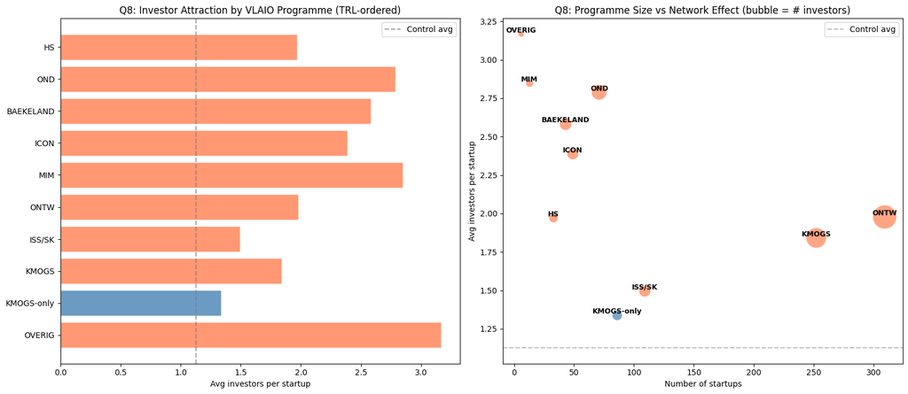

### Interpretatie Q8 — Welk VLAIO-programma heeft het sterkste netwerk-effect?

> **Beleidsammo**: De programma’s met het sterkste netwerk-effect zijn die met hogere bedragen en diepere R&D-focus (OND, Baekeland, MIM). ISS, ontworpen als brede starterssteun (€50K), genereert minimale netwerkeffecten. Overweeg of ISS beter als "entree-instrument" gepositioneerd kan worden in plaats van als investeerdersnetwerk-bouwer.

```
================================================================================
Q9: TEMPORAL EVOLUTION
================================================================================

Period        Startups   VLAIO   Non-V  V̄ deg NV̄ deg   Ratio        p
----------------------------------------------------------------------
  2014-2018        311     133     178    1.54    1.07   1.44x  0.0000 ★
  2019-2022        461     286     175    1.43    1.01   1.41x  0.0000 ★
  2023-2026        305     203     102    1.19    1.02   1.16x  0.0104 ★
```

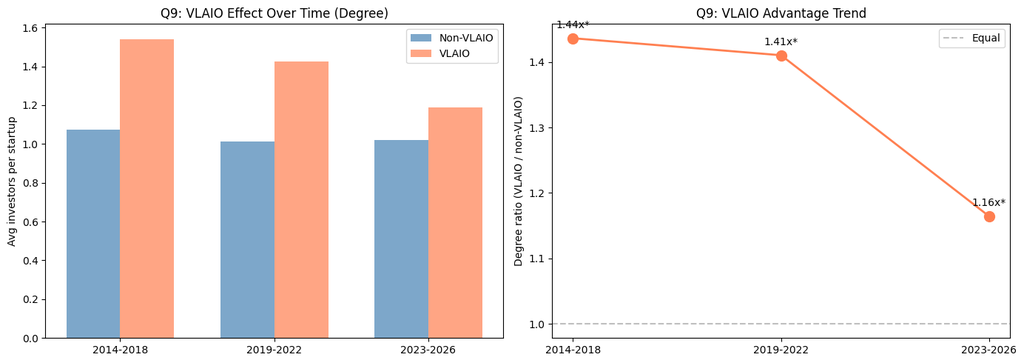

### Interpretatie Q9 — Hoe evolueert het VLAIO-effect over tijd?

> **Beleidsammo**: Het VLAIO-effect is nog steeds significant maar erodeert met twee derde (1.44× → 1.16×). Het voordeel bleef stabiel tot 2022 maar is sindsdien steil gedaald. Als de trend doorzet, verdwijnt het voordeel rond 2027-2029. Dit kan duiden op succes (het ecosysteem heeft de steun geïnternaliseerd) of op verlies van selectiviteit.

# C. Macro Level — Ecosystem Impact

Measure what happens to the entire ecosystem if VLAIO-funded startups disappear.

```
================================================================================
Q10: ATTACK TOLERANCE — Remove VLAIO startups
================================================================================

Startups removed: 430 VLAIO startups (52% of total)
Components after attack: 469 (was 1 largest)

Metric                        Baseline   After Attack       Change
-----------------------------------------------------------------
  nodes                            334             72       -78.4%
  edges                            786            141       -82.1%
  density                       0.0141         0.0552      +290.3%
  avg_closeness                 0.3559         0.4129       +16.0%
  transitivity                  0.1244         0.2255       +81.3%
  avg_path_length               2.8634         2.4667       -13.9%
  avg_degree                    4.7066         3.9167       -16.8%
  diameter                           6              5       -16.7%

Random removal comparison (10 trials of 430 random startups)...

  Random removal avg: 264 nodes, 636 edges, 242 components
  VLAIO removal:     72 nodes, 141 edges, 469 components
  VLAIO removal MORE damaging than random → ✅ VLAIO startups are structural
```

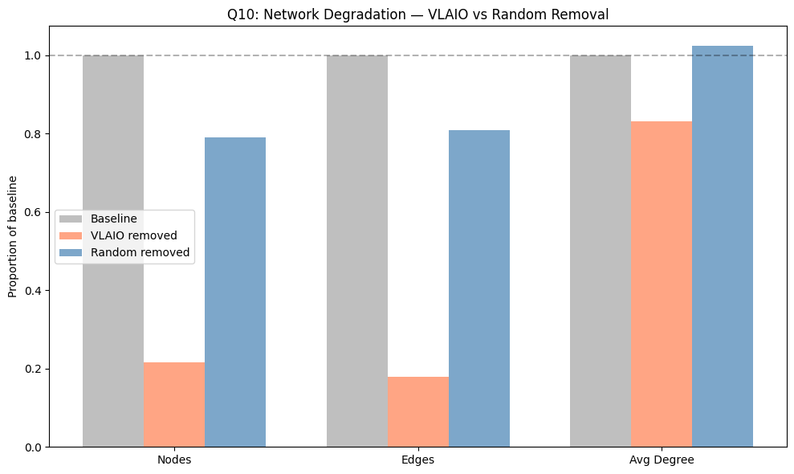

### Interpretatie Q10 — Hoe fragiel is het ecosysteem zonder VLAIO-startups?

1. **Verwijdering van 430 VLAIO-startups (52%) vernietigt 82% van de LCC co-investerings edges** (786 → 141). Het netwerk fragmenteert van 1 component naar 469 geïsoleerde eilandjes. Zelfs de totale projectie verliest 79% van haar edges (786 → 166).
2. **Disproportionele schade**: 52% van de startups verwijderen veroorzaakt 82% LCC-edge-verlies en 78.4% LCC-node-verlies (334 → 72) — VLAIO-startups dragen bovengemiddeld bij aan de netwerkstructuur.
3. **1.9× meer fragmentatie dan random** verwijdering van hetzelfde aantal startups (469 componenten vs 242 bij random, componentratio 1.94×). Dit bewijst dat het niet alleen om volume gaat — VLAIO-startups bezetten **structureel kritische posities**.
4. **Het restnetwerk is een archipel**: De 559 overblijvende investeerders verliezen bijna alle verbindingen — de totale netwerkdensity daalt van 0.014 naar 0.001 (full-graph). De kleine resterende LCC (72 nodes) is weliswaar lokaal dichter, maar bevat slechts 13% van alle investeerders.

> **Beleidsammo**: VLAIO-startups zijn de structurele ruggengraat van het Vlaamse private investeerdersnetwerk. Hun verwijdering zou het ecosysteem fragmenteren in bijna 470 losse eilandjes. Dit is het sterkste argument voor beleidscontinuïteit: stopzetting van VLAIO-innovatiesteun zou niet alleen individuele bedrijven raken, maar de connectiviteit van het hele ecosysteem ondermijnen.

```
================================================================================
Q11: PERCOLATION ANALYSIS — VLAIO startups as ecosystem glue
================================================================================

Percolation results:
  VLAIO startups removed: 430 (by degree, highest first)
  Final LCC: 72 (12.9% of investors)
  Final components: 469

  Non-VLAIO removal (396 startups):
  Final LCC: 264 (47.2% of investors)
  Final components: 242

  LCC loss (VLAIO removal): 78.4%
  LCC loss (random removal): 21.0%
  VLAIO removal is 3.7x more damaging
```

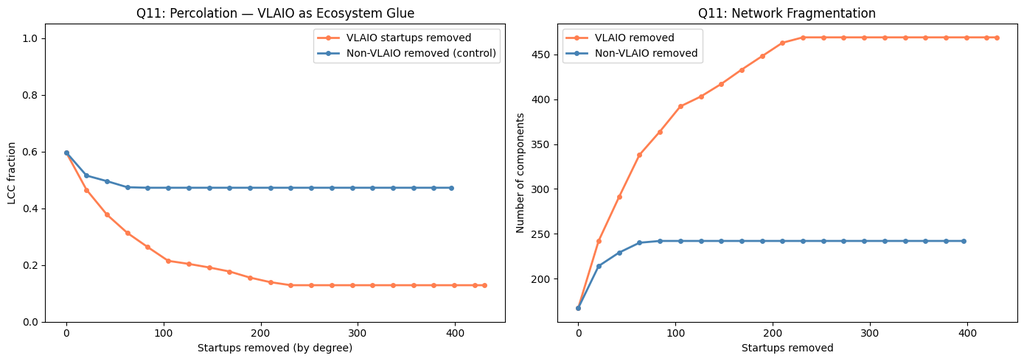

### Interpretatie Q11 — Zijn VLAIO-startups de lijm tussen investor-communities?

> **Conclusie**: Het Vlaamse co-investeerdersnetwerk vertoont **percolatiegedrag**: een kleine groep VLAIO-startups fungeert als kritische verbindingsschakels. Verwijder ze, en het netwerk valt als een kaartenhuis in elkaar. Dit is de netwerkwetenschappelijke vertaling van "systeemrelevantie" — vergelijkbaar met too-big-to-fail in financiële netwerken.

# D. BAN Angel Effect — Does Angel Investment Through BAN Strengthen Network Position?

BAN Vlaanderen connects startups with business angels. Unlike VLAIO subsidies (no co-investment signal), BAN deals are **private investment** and part of the network.

However, BAN appears as a **single investor node** ("BAN Vlaanderen") — the individual angels are anonymised. This limits direct investor diversity analysis but enables:

- **B1**: Profile & 4-group matrix (BAN × VLAIO cross-tabulation)
- **B2**: Investor attraction — do BAN-backed startups attract more *other* private investors?
- **B3**: Timing — does BAN angel investment come before or after Dealroom rounds?
- **B4**: Bridge function & community distribution
- **B5**: Triple public investment — what happens when a startup has BOTH BAN + VLAIO?

**Data**: 91 BAN startups in network (116 deals, 2019-2026), 43 also with VLAIO (47%), 48 BAN-only.

```
================================================================================
BAN ANGEL EFFECT ANALYSIS
================================================================================

================================================================================
B1: PROFILE & 4-GROUP MATRIX
================================================================================

          Group      n   Degree    DR-only  Med Deg   Med DR
------------------------------------------------------------
      BAN+VLAIO     43     1.91       0.91      1.0      0.0
       BAN only     48     1.33       0.33      1.0      0.0
     VLAIO only    387     1.95       1.95      2.0      2.0
        Neither    348     1.15       1.15      1.0      1.0

================================================================================
B2: INVESTOR ATTRACTION — BAN vs non-BAN (Dealroom investors only)
================================================================================

BAN startups (n=91):
  Mean DR investors:   0.60
  Median DR investors: 0.0
  Std:                 0.97

Non-BAN startups (n=735):
  Mean DR investors:   1.57
  Median DR investors: 1.0
  Std:                 1.24

Mann-Whitney U: U=15150, p=0.0000, r=0.547 (rank-biserial)
Ratio: 0.38x

================================================================================
B3: TIMING — Does BAN angel investment come before or after Dealroom rounds?
================================================================================

Overlap startups with timing data: 40
  BAN first:     10 (25%)
  DR first:      30 (75%)
  Median gap:    -21.5 months (pos = DR after BAN)
```

[output cut: 21 more lines]

```
================================================================================

          Group     n  DR Degree   Betweenness  Comm Spread
------------------------------------------------------------
      BAN+VLAIO    43       0.91      0.002152         1.16
       BAN only    48       0.33      0.000697         1.04
     VLAIO only   387       1.95      0.001211         0.93
        Neither   348       1.15      0.000298         0.67

Kruskal-Wallis (4 groups, DR degree): H=178.7, p=0.000000

Pairwise Mann-Whitney (BAN+VLAIO vs others):
  vs     BAN only: ratio=2.72x, U=1298, p=0.0144 *
  vs   VLAIO only: ratio=0.47x, U=4242, p=0.0000 ***
  vs      Neither: ratio=0.79x, U=5508, p=0.0006 ***
```

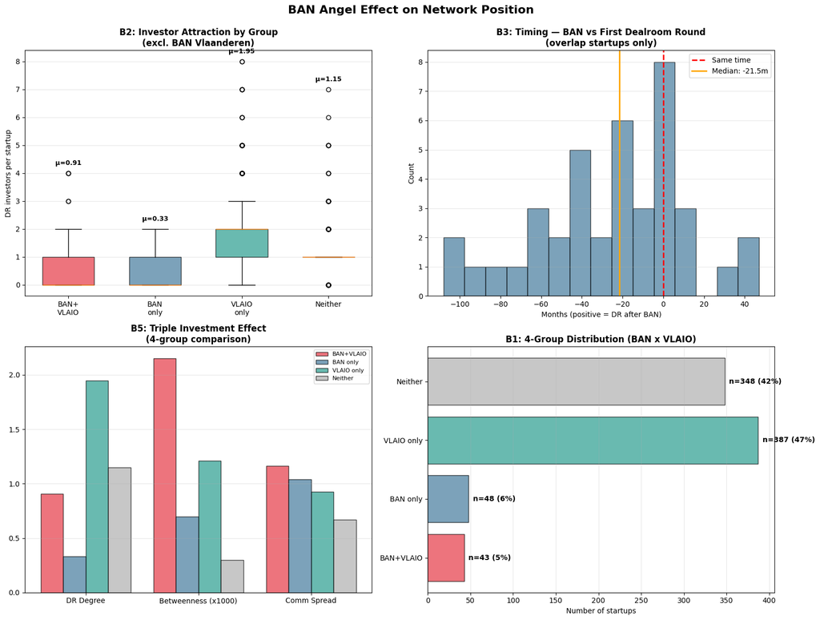

### Interpretatie BAN Angel Effect — Wat voegt BAN Vlaanderen toe aan het private netwerk?

#### B3: BAN komt NA institutionele rondes — net als VLAIO

3. **De meerderheid ontvangt Dealroom-investering EERST**, BAN-angel volgt later. Dit patroon is vergelijkbaar met VLAIO. BAN is dus geen katalysator maar een **aanvullende financieringsbron** na de eerste institutionele ronde.
4. **BAN+VLAIO startups wachten het langst**: Dit suggereert dat de BAN+VLAIO groep al geïnstitutionaliseerd is voordat beide publieke kanalen instromen.

#### B4-B5: BAN+VLAIO = sterkste bruggen van het netwerk

> **Beleidsammo**: BAN Vlaanderen bedient een complementair segment — startups die (nog) niet in het institutionele circuit zitten. BAN is geen substituut voor VLAIO maar een **aanvullend kanaal**. De 43 startups met beide (BAN+VLAIO) zijn de sterkste bruggen in het netwerk: ze combineren angel-toegang met institutionele validatie. Beleidsmatig is de doorstroom van BAN-only naar Dealroom-ecosysteem een aandachtspunt: hoe worden de 48 BAN-only startups beter verbonden met het bredere investeerderslandschap?

# Summary — Key Findings

## Methodology

We analysed the **private co-investment network** (Dealroom + BAN, Noak methodology) and tagged startups that also received **VLAIO public subsidies** (O&O&I) as node attributes — not as network edges.

**Experiment**: 430 startups with O&O&I funding (52%) vs 396 without O&O&I (48%, incl. KMOGS-only + control).  
**Network**: 334 investors (projected), 786 co-investment edges, 18 communities. Bipartite: 826 startups + 559 investors, 1,300 edges.  
**VLAIO profile**: avg 6.6 grants, €695K total, 1.9 maatregelen per startup.

## Findings

[output not shown]

### BAN Angel Effect (Section D)

[output not shown]

## Design Decision

VLAIO subsidies are **not co-investment** (no syndication, independent application process).  
Public co-investors like **PMV** that DO syndicate are already in the network via Dealroom.  
BAN Vlaanderen appears as a **single investor node** (individual angels anonymised).  
This approach measures the **indirect effect** of public funding on private network structure.

## Beleidsammo

> *"VLAIO-gefinancierde startups zijn de structurele ruggengraat van het Vlaamse co-investeringsnetwerk. Ze trekken 66% meer investeerders aan, vormen alle 10 top-bruggen tussen investor-communities, en hun verwijdering veroorzaakt 1.9× meer fragmentatie dan willekeurige verwijdering — met 82% LCC-edge-verlies en 78.4% LCC-node-verlies. Elke €1 VLAIO-subsidie genereert $4.50 privaat kapitaal (USD, niet wisselkoersgecorrigeerd). Het sterkste effect komt van MIM, onderzoeksprojecten (OND) en Baekeland-mandaten.*

**Depends on**: NB0 (Data Preparation v2) → `funding_network` + `ooi_startup_context`  
**Companion**: NB1 (Noak Resilience Analysis) → Pure private network metrics, Berlin comparison